# Floraison : Melon et pinot auxerrois

Gabriel Macé

2025-04-01

## Objectifs :

Dans nos modèles de simulations de la floraison de la vigne, il nous manque les paramètres concernant la floraison de deux cépages : le melon, et le pinot auxerrois.

Nous allons essayer de simuler ces dates de floraison, soit en estimant un paramètre : le nombre de degré-jour nécessaires, soit en se basant sur la simulation d’un autre cépage, comme nous avions pu le faire pour le débourrement grâce à plantGrape.fr.

! Pour le calcul de degrès cumulés : j’ai pris la moyenne entre le min et le max par jour, pour être cohérent avec nos modèles de phénologie.

## I - Melon :

Pour le melon, nous allons nous baser sur des données issues du domaine expérimental de l’IFV à Montreuil-Bellay de 2008 à 2022 (sans 2015 et 2016), et les données climatiques correspondantes, issues d’une station météo.

### Comparaison inter-cépages :

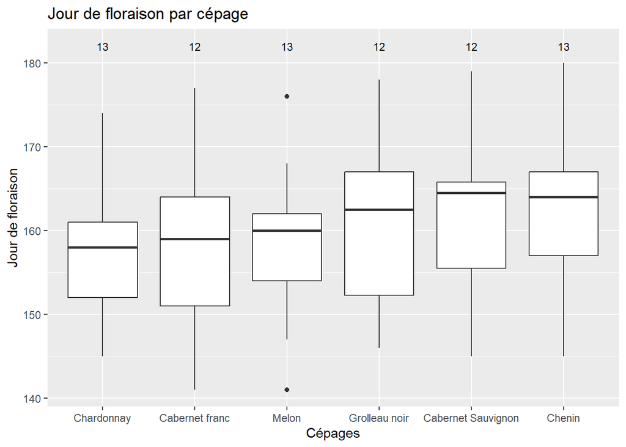

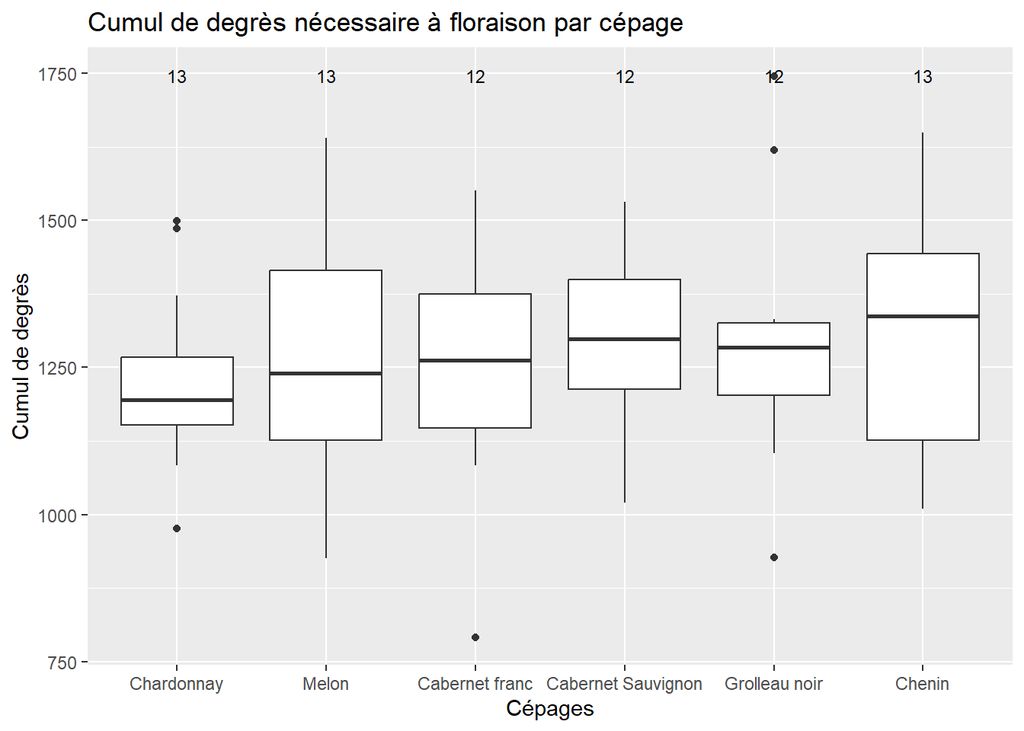

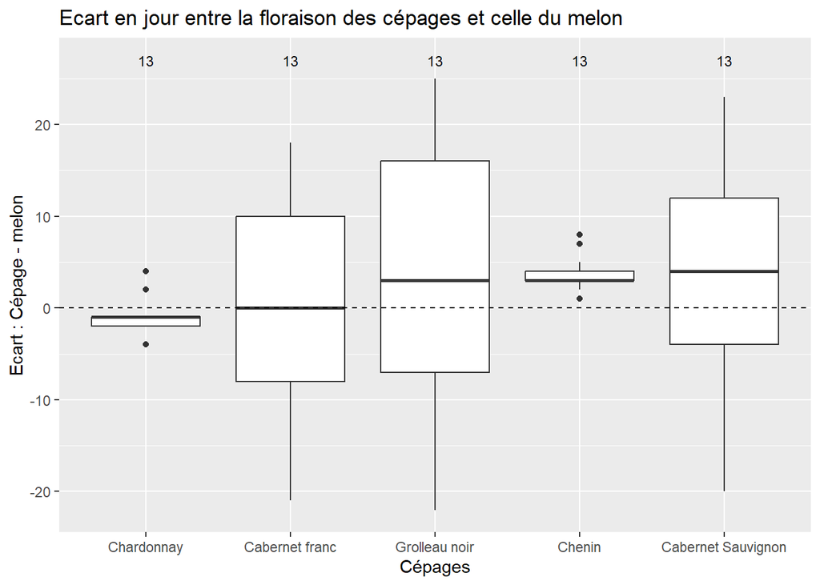

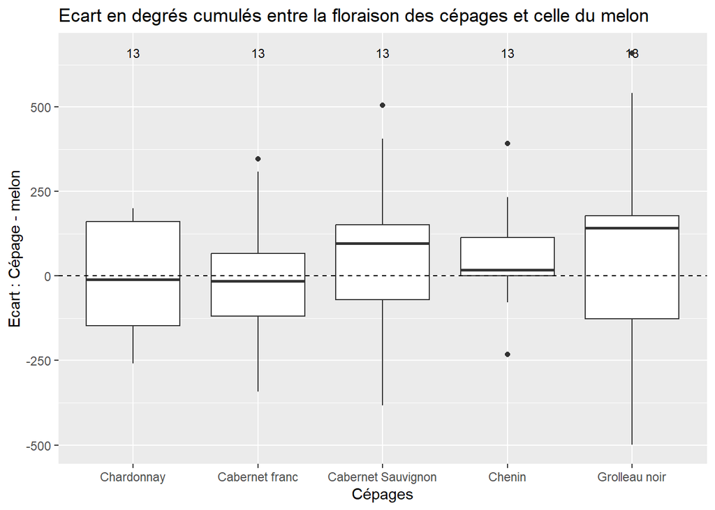

Calcul des RMSE entre la floraison du melon et des autres cépages :

```
## [1] "RMSE par cépages (jours) :"
```

```
## [1] "Cabernet franc : 11.46"
```

```
## [1] "Cabernet Sauvignon : 12.63"
## [1] "Chenin : 4.19"
```

```
## [1] "Grolleau noir : 13.84"
## [1] "Chardonnay : 2.17"
```

```
## [1] "RMSE par cépages (degrès cumulés) :"
```

```
## [1] "Cabernet franc : 194.89"
```

```
## [1] "Cabernet Sauvignon : 252.56"
## [1] "Chenin : 155.53"
```

```
## [1] "Grolleau noir : 325.38"
## [1] "Chardonnay : 163.94"
```

Calcul des écarts médians entre la floraison du melon et des autres cépages :

```
## [1] "Ecart médian avec le melon en jour :"
```

```
## # A tibble: 5 × 2
##   cepage             date_median
##   <chr>                    <dbl>
## 1 Cabernet Sauvignon           4
## 2 Cabernet franc               0
## 3 Chardonnay                  -1
## 4 Chenin                       3
## 5 Grolleau noir                3
```

```
## [1] "Ecart moyen avec le melon en jour :"
```

```
## # A tibble: 5 × 2
##   cepage             date_mean
##   <chr>                  <dbl>
## 1 Cabernet Sauvignon     3.85
## 2 Cabernet franc         0.154
## 3 Chardonnay            -1
## 4 Chenin                 3.69
## 5 Grolleau noir          3.54
```

```
## [1] "Ecart médian avec le melon en degrès cumulés :"
```

```
## # A tibble: 5 × 2
##   cepage             degres_cumules_median
##   <chr>                              <dbl>
## 1 Cabernet Sauvignon                  97.2
## 2 Cabernet franc                     -15
## 3 Chardonnay                         -10.5
## 4 Chenin                              17.7
## 5 Grolleau noir                      142
```

```
## [1] "Ecart moyen avec le melon en degrès cumulés :"
```

```
## # A tibble: 5 × 2
##   cepage             degres_cumules_mean
##   <chr>                            <dbl>
## 1 Cabernet Sauvignon               58.8
## 2 Cabernet franc                    5.69
## 3 Chardonnay                      -15.9
## 4 Chenin                           60.0
## 5 Grolleau noir                    71.7
```

Au vu des écarts de floraison entre ces différents cépages et le melon, le cépage le plus proche du melon en terme de date floraison semble être le cabernet franc, avec un écart médian de 0 jours.

Cependant, cela est moins évident en regardant le nombre de degrés cumulés, mais surtout les dates de floraison du chardonnay et du melon obtiennent la petite rmse, ce qui est du à la très petite variabilité de leurs écarts : il y a un écart très régulier : La date de floraison du melon est très souvent un jour ou deux jours après celle du chardonnay.

Il faudrait peut être plus se fier à cette deuxième relation pour prédire la floraison du melon.

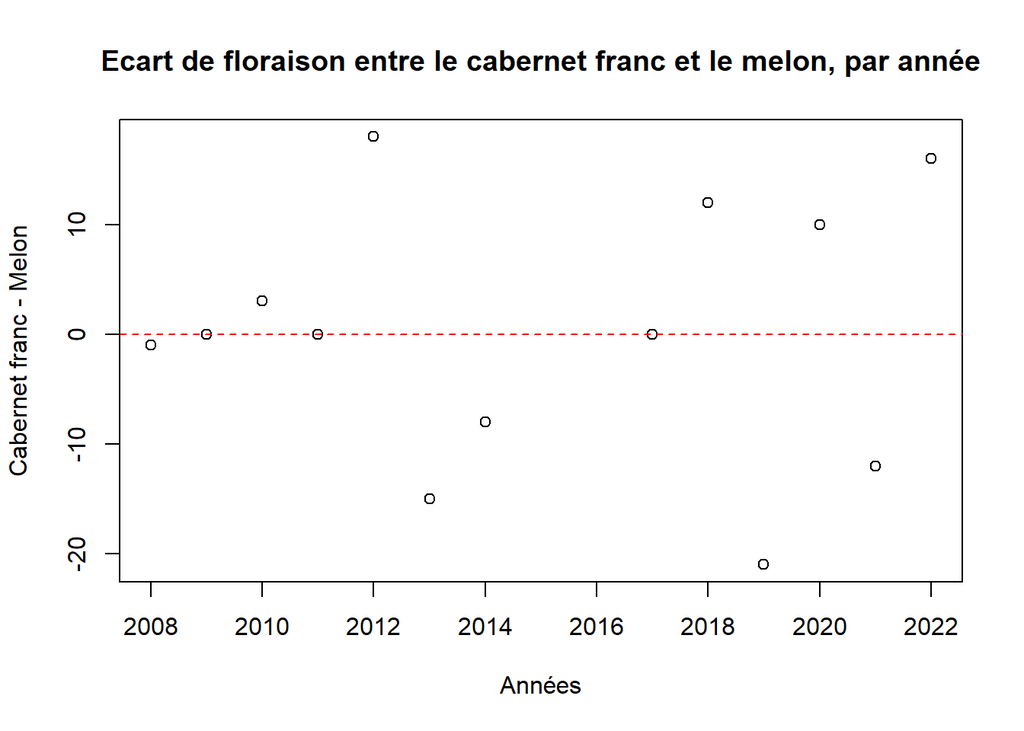

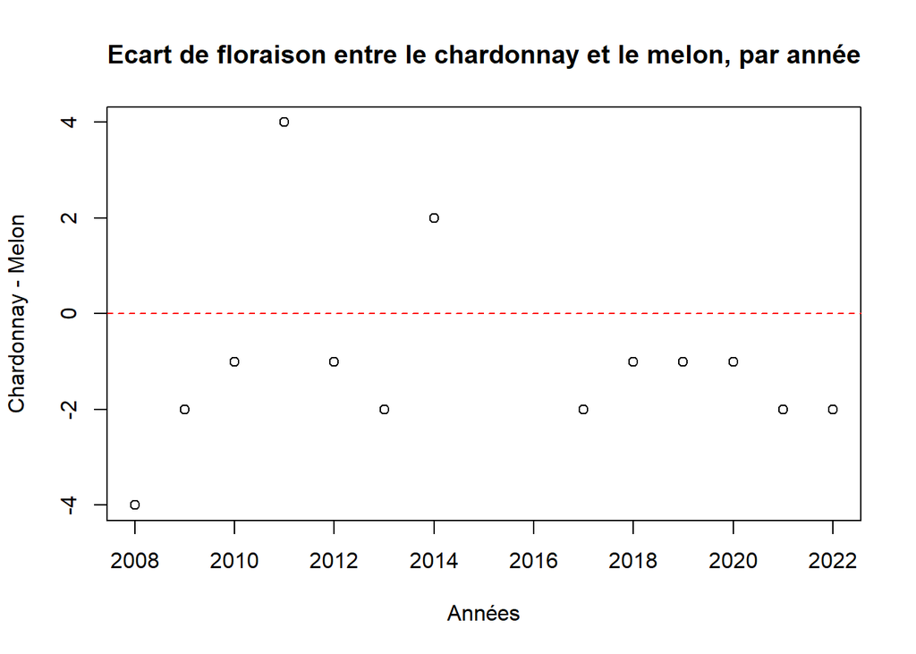

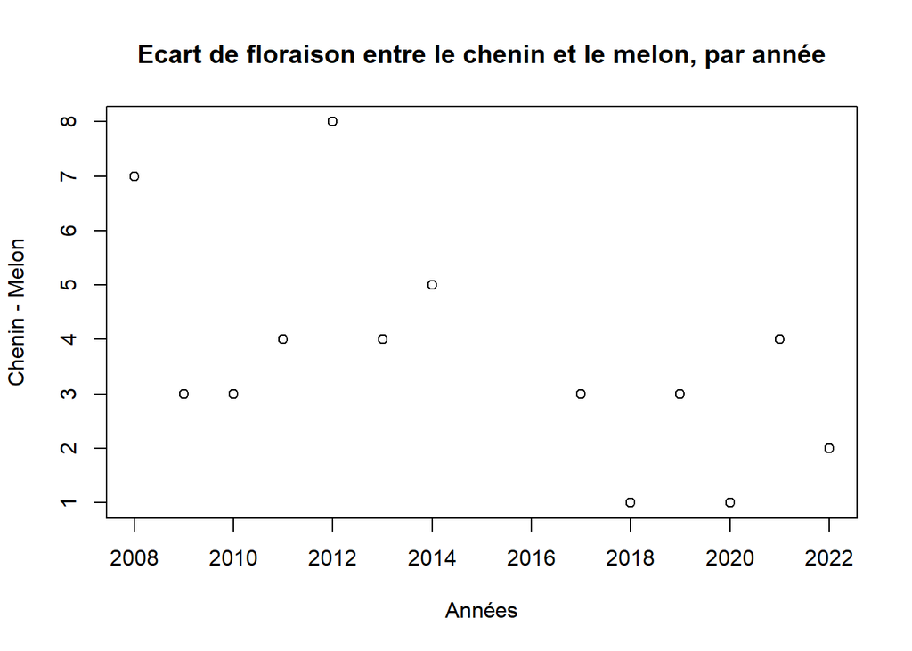

Représentativité des dates de floraison par rapport aux paramètres du modèle gfv :

```
## [1] "Cumul de degrès jours nécessaire pour le cabernet franc dans gfv : 1225"
```

```
## [1] "Ici : 1262.025"
```

```
## [1] "Cumul de degrès jours nécessaire pour le cabernet sauvignon dans gfv : 1270"
```

```
## [1] "Ici : 1298.25"
```

```
## [1] "Cumul de degrès jours nécessaire pour le chenin dans gfv : 1280"
```

```
## [1] "Ici : 1337.55"
```

```
## [1] "Cumul de degrès jours nécessaire pour le chardonnay dans gfv : 1217"
```

```
## [1] "Ici : 1195.4"
```